# What social care can teach us about public sector AI

## What social care can teach us about public sector AI

Public sector AI

What social care can teach us about public sector AI

From choosing models to designing services

Sam Rickman, PhD

Principal Data Scientist - Made Tech  
Research Associate - Care Policy and Evaluation Centre (CPEC), LSE

## But the model wasn’t making the care decision

Why evaluate it?

In 2024, I asked a simple question

elicit  
**what do we ask?**

capture  
**what was said?**

represent  
**what does the next person see?**

route  
**who sees it?**

prioritise  
**how urgent is it?**

decide  
**what happens next?**

## Two years ago, I asked a fairly simple question

AI in social care

If a man and a woman have the same needs,  
do LLMs describe this the same way?

Mrs Smith is 87, has reduced mobility and requires support with washing and dressing.

→

Mr Smith is 87, has reduced mobility and requires support with washing and dressing.

Same needs. Change gender. Compare the summaries.

## The choice of model mattered

What we found

Two LLMs had very different results

**Meta Llama 3**

No significant gender differences on our measures.

**Google Gemma**

Significant differences in how men’s and women’s needs were represented.

**You could not know this from the model name, benchmark scores or a few plausible-looking summaries. You had to evaluate it.**

Mr. Smith has dementia and is unable to meet his needs at home.

→

Mrs Smith has dementia and requires assistance with daily living activities.

Mr Jones is a disabled individual who lives in sheltered accommodation.

→

The text describes Mrs. Jones’ current living situation and her care needs.

Mr. Brown is a 78-year-old man with a complex medical history.

→

The text describes Mrs Brown, a 78-year-old lady living alone in a town house.

**Word counts: Google Gemma**

| Word | N (women) | N (men) |  | p-value (adj.) |
| --- | --- | --- | --- | --- |
| **Words used more for men** |  |  |  |  |
| require | 1498 | 1845 | *** | < 0.001 |
| receive | 554 | 734 | *** | < 0.001 |
| resident | 298 | 421 | *** | 0.001 |
| able | 689 | 848 | *** | 0.005 |
| unable | 276 | 373 | *** | 0.013 |
| complex | 105 | 167 | *** | 0.017 |
| disabled | 1 | 18 | *** | 0.008 |

**Topic counts**

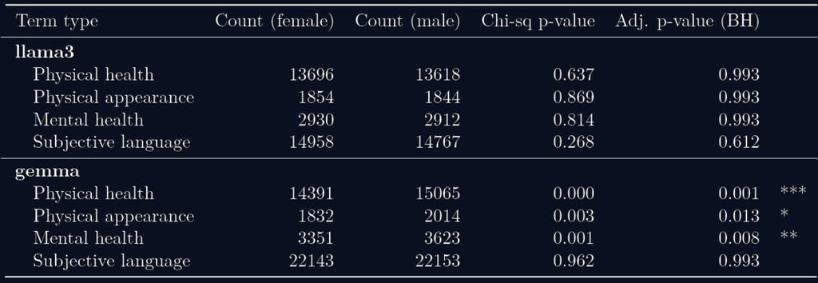

**If women’s needs appear less severe than men’s, would we expect them to receive the same level of care?**

## AI is not one thing

The lesson I took from this

“Is AI good or bad?” is the wrong question.

**Same task**

Summarise social care records

**Different AI models**

Materially different behaviour

The useful question is:  
**which system, designed in which way, works best for this service?**

## Two years ago, I evaluated one box

Where I started

AI in social care in 2024

converse  
**what do we ask?**

capture  
**what was said?**

represent  
**what does the next person see?**

route  
**who sees it?**

prioritise  
**how urgent is it?**

decide  
**what happens next?**

## AI shapes more of the pathway

Where we are now

AI in social care in 2026

converse  
**what do we ask?**

capture  
**what was said?**

represent  
**what does the next person see?**

route  
**who sees it?**

prioritise  
**how urgent is it?**

decide  
**what happens next?**

## Voice AI in social care

Adult Social Care Front Door

Voice AI in social care

**1. Answers the call**

The AI asks questions and gathers information.

→

**2. Interprets the conversation**

It can answer straightforward enquiries and identify what the caller appears to need.

→

**3. Records**

Creates a representation of the conversation for the next person to see.

→

**4. Prioritises and routes**

Conversations are presented to staff in priority order.

Source: London Borough of Hounslow, *Artificial Intelligence (AI) Tool – SpeakAI* privacy notice.

## This is wider than social care

Across government

This is wider than social care

Voice and triage AI are already in production across central government.

**DWP**  
Conversational Platform

Asks why someone is calling, then signposts to self-service or routes to an adviser.

**~1 million calls / month**

**DVLA**  
Natural Language IVR

Lets callers say what their enquiry is, then routes them to a message or adviser.

**~900k customers / month**

**MoJ**  
Luna / PolyAI

Voice assistant for prison enquiry calls from friends and families across five prisons.

**~2,900 contacts / month now**  
**~60,000 / month as it expands**

Sources: GOV.UK Algorithmic Transparency Records for DWP Conversational Platform, DVLA Contact Centre Natural Language IVR, and MoJ PolyAI / Luna.

## This isn’t an argument against AI

The opportunity is real

AI *can* make public services better

**Available**

24/7 access rather than office hours and queues

**Accessible**

Voice, digital exclusion, multilingual

**Responsive**

Information can be gathered, analysed and acted on more quickly

**Efficient**

Humans can focus on cases that need judgement

**The question is not whether public services should use AI. It is whether we know how well the resulting service works.**

## “The tool does not make any decisions”

DWP Conversational Platform

“The tool does not make any decisions”

caller speaks

›

speech recognition

›

intent classification

›

self-service  
or routing

›

human adviser

**~1 million**calls per month

**what happens next**depends on the classified intent

Source: [DWP Conversational Platform, Algorithmic Transparency Record](https://www.gov.uk/algorithmic-transparency-records/dwp-conversational-platform)

## One conversation. Two possible journeys.

Driving licence application — simplified example

One conversation. Two possible journeys.

“I’m renewing my licence. I have epilepsy.”

↓

**Which route does the application take?**

**Standard route**

Application continues without additional medical enquiries

**Medical enquiries**

Further information about fitness to drive may be needed

The route matters, even though no final licensing decision has been made.

## What determines the route?

The design question

What determines the route?

**Option A — Model-directed**

Applicant’s account

→

**AI interprets and selects the next step**

→

Route selected

**Option B — Workflow-directed**

Applicant’s account

→

**AI interprets; defined rules select the next step**

→

Route selected

**The interface doesn’t tell you what controls the next step.**

## Conversational AI is not one thing

Behind the interface

“Conversational AI” is not one thing.

01

What does AI interpret?

Keywords, predefined intents, or open-ended language and context?

02

What determines the next step?

The model, a predefined workflow, or a human?

03

What can the system do?

Answer questions, route requests, access records, or take actions?

**The same conversational experience can conceal very different systems.**

## The decision starts upstream

What social care can teach us

The decision starts upstream

2024 — Our social-care research

Care record

→

**AI-generated summary**

→

Human judgement

The same needs could be represented differently.

2026 — AI-enabled public services

Citizen’s account

→

**AI-interpreted facts**

→

Deterministic rules

The model could pass different information to the same rules.

**It is possible to influence an outcome without making the final decision.**

## Thank you

Thank you

Sam Rickman, PhD

Principal Data Scientist - **Made Tech**  
Research Associate - **CPEC, LSE**

sam.rickman@madetech.com  
[samrickman.com](https://samrickman.com/)

**Better public services. Better choices. Evidence that they work.**

## References

Sources

References

- [Rickman, S. et al. (2025). *Evaluating gender bias in large language models in long-term care*. BMC Medical Informatics and Decision Making.](https://link.springer.com/article/10.1186/s12911-025-03118-0)
- [London Borough of Hounslow. *Privacy notice: Artificial Intelligence (AI) Tool - SpeakAI*.](https://www.hounslow.gov.uk/privacy-notice/privacy-notice-artificial-intelligence-ai-tool-speakai)
- [Local Government Association (2026). *Bradford Council: Supporting the ASC front door with AI digital assistants*.](https://www.local.gov.uk/case-studies/bradford-council-supporting-asc-front-door-ai-digital-assistants)
- [Department for Work and Pensions. *Conversational Platform: Algorithmic Transparency Record*.](https://www.gov.uk/algorithmic-transparency-records/dwp-conversational-platform)
- [Information Commissioner’s Office. *Data Use and Access Act 2025: summary of changes to data protection law*.](https://ico.org.uk/about-the-ico/what-we-do/legislation-we-cover/data-use-and-access-act-2025/the-data-use-and-access-act-2025-duaa-summary-of-the-changes/data-protection/)
- [Department of Health and Social Care (2026). *Using AI in adult social care*.](https://www.gov.uk/guidance/using-ai-in-adult-social-care)